# UMN_traveler_project_2019

Author: Ganghua Wang

Department of Statistics, University of Minnesota

Email: wang9019@umn.edu

## Intro

This jupyter notebook is served as a personal summary and memo for UMN_traveler project 2019. Here is a link to Kaggle project homepage: https://www.kaggle.com/c/mn2019comp/overview.

I'll introduce my procedure to deal the data and model.

## Import neccesary pacakges

```python
import pandas as pd
import numpy as np
import missingno as msno
import seaborn as sns
import matplotlib.pyplot as plt
from tools import visualize_missing, plt_dist, heat_map, modelfit, grid_searchCV, clip, train_model_classification
%matplotlib inline
```

## Data overview

We have three data files, take policies.csv for example.

Some useful functions for overview:

- df.columns
- df.head()
- df.info()
- df.describe()
- df.nunique()
- df.isnull()

Please refer to documentations for details.

### Basic information

```python
policy_df = pd.read_csv('data/policies.csv', index_col=0)
policy_df.columns.values
```

```
array(['Quote_dt', 'discount', 'Home_policy_ind', 'zip', 'state_id',
       'county_name', 'Agent_cd', 'quoted_amt', 'Prior_carrier_grp',
       'credit_score', 'Cov_package_type', 'CAT_zone', 'policy_id',
       'number_drivers', 'num_loaned_veh', 'num_owned_veh',
       'num_leased_veh', 'total_number_veh', 'convert_ind', 'split',
       'primary_parking'], dtype=object)
```

```python
f' We have in total {len(policy_df.columns.values)} raw features.'
```

```
' We have in total 21 raw features.'
```

```python
f' The shape of data is {policy_df.shape}'
```

```
' The shape of data is (49162, 21)'
```

```python
policy_df.head()
```

|  | Quote_dt | discount | Home_policy_ind | zip | state_id | county_name | Agent_cd | quoted_amt | Prior_carrier_grp | credit_score | ... | CAT_zone | policy_id | number_drivers | num_loaned_veh | num_owned_veh | num_leased_veh | total_number_veh | convert_ind | split | primary_parking |
| --- | --- | --- | --- | --- | --- | --- | --- | --- | --- | --- | --- | --- | --- | --- | --- | --- | --- | --- | --- | --- | --- |
| 1 | 2015-01-28 | Yes | Y | 10465.0 | NY | Bronx | 15973623.0 | $5,153 | Carrier_1 | 613.0 | ... | 2.0 | policy_87209 | 2 | 1 | 2 | 0 | 3 | 0.0 | Train | home/driveway |
| 2 | 2015-02-12 | No | N | 12801.0 | NY | Warren | 46978147.0 | $9,870 | Carrier_4 | 576.0 | ... | 4.0 | policy_89288 | 1 | 1 | 1 | 2 | 4 | NaN | Test | unknown |
| 3 | 2018-09-03 | No | N | 11548.0 | NY | Nassau | 32759856.0 | $3,090 | Carrier_4 | 631.0 | ... | 2.0 | policy_91413 | 2 | 1 | 2 | 1 | 4 | 0.0 | Train | unknown |
| 4 | 2015-07-28 | No | N | 33141.0 | FL | Miami-Dade | 47310293.0 | $2,860 | Carrier_7 | 573.0 | ... | 3.0 | policy_23460 | 1 | 2 | 3 | 0 | 5 | NaN | Test | unknown |
| 5 | 2016-05-18 | No | N | 14622.0 | NY | Monroe | 15675431.0 | $14,917 | Carrier_3 | 602.0 | ... | 4.0 | policy_71845 | 2 | 0 | 1 | 2 | 3 | 0.0 | Train | unknown |

5 rows × 21 columns

```python
policy_df.info()
```

```
<class 'pandas.core.frame.DataFrame'>
Int64Index: 49162 entries, 1 to 49162
Data columns (total 21 columns):
Quote_dt             49162 non-null object
discount             49162 non-null object
Home_policy_ind      49162 non-null object
zip                  48690 non-null float64
state_id             49162 non-null object
county_name          49162 non-null object
Agent_cd             43732 non-null float64
quoted_amt           49050 non-null object
Prior_carrier_grp    44162 non-null object
credit_score         48862 non-null float64
Cov_package_type     48392 non-null object
CAT_zone             48912 non-null float64
policy_id            49162 non-null object
number_drivers       49162 non-null int64
num_loaned_veh       49162 non-null int64
num_owned_veh        49162 non-null int64
num_leased_veh       49162 non-null int64
total_number_veh     49162 non-null int64
convert_ind          36871 non-null float64
split                49162 non-null object
primary_parking      49162 non-null object
dtypes: float64(5), int64(5), object(11)
memory usage: 8.3+ MB
```

```python
policy_df.describe()
```

|  | zip | Agent_cd | credit_score | CAT_zone | number_drivers | num_loaned_veh | num_owned_veh | num_leased_veh | total_number_veh | convert_ind |
| --- | --- | --- | --- | --- | --- | --- | --- | --- | --- | --- |
| count | 48690.000000 | 4.373200e+04 | 48862.000000 | 48912.000000 | 49162.000000 | 49162.000000 | 49162.000000 | 49162.000000 | 49162.000000 | 36871.000000 |
| mean | 22515.226515 | 5.459507e+07 | 641.422066 | 2.874407 | 2.162117 | 1.306131 | 1.648570 | 0.500142 | 3.454843 | 0.111741 |
| std | 15691.485404 | 2.527024e+07 | 78.960389 | 1.440565 | 1.239114 | 0.900568 | 0.726165 | 0.668482 | 1.336875 | 0.315052 |
| min | 6051.000000 | 1.278836e+07 | 369.000000 | 1.000000 | 1.000000 | 0.000000 | 1.000000 | 0.000000 | 1.000000 | 0.000000 |
| 25% | 10007.000000 | 3.261900e+07 | 582.000000 | 2.000000 | 1.000000 | 1.000000 | 1.000000 | 0.000000 | 2.000000 | 0.000000 |
| 50% | 13088.000000 | 5.332332e+07 | 642.000000 | 3.000000 | 2.000000 | 1.000000 | 1.000000 | 0.000000 | 3.000000 | 0.000000 |
| 75% | 33317.000000 | 7.644067e+07 | 698.000000 | 4.000000 | 3.000000 | 2.000000 | 2.000000 | 1.000000 | 4.000000 | 0.000000 |
| max | 56075.000000 | 9.957344e+07 | 850.000000 | 5.000000 | 6.000000 | 3.000000 | 3.000000 | 2.000000 | 8.000000 | 1.000000 |

```python
policy_df.nunique()
```

```
Quote_dt              1460
discount                 2
Home_policy_ind          2
zip                   1168
state_id                 8
county_name            112
Agent_cd              1688
quoted_amt           14380
Prior_carrier_grp        9
credit_score           422
Cov_package_type         3
CAT_zone                 5
policy_id            49162
number_drivers           6
num_loaned_veh           4
num_owned_veh            3
num_leased_veh           3
total_number_veh         8
convert_ind              2
split                    2
primary_parking          4
dtype: int64
```

### Visualize missing values

```
                   missing
zip                    472
Agent_cd              5430
quoted_amt             112
Prior_carrier_grp     5000
credit_score           300
Cov_package_type       770
CAT_zone               250
convert_ind          12291
```

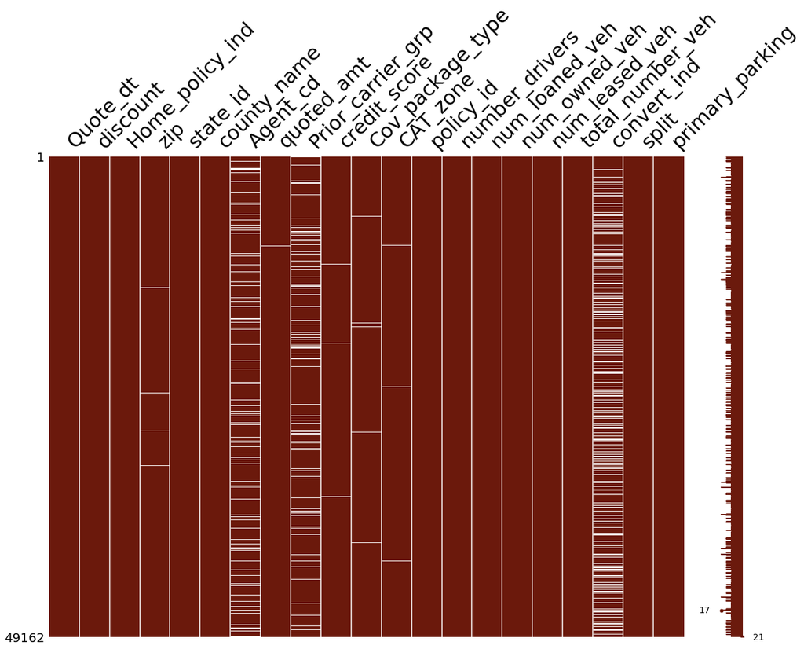

```python
visualize_missing(policy_df)
```

Some observations:

- Cat_zone, indicator, is nominated or ranked? (1-5)
- number of vehicles, collinear
- number of drivers, indicator (1-6)
- Cover_package_type, indicator (High, Low, Medium)
- Zip-county-state, three levels of regions

Further comments:

- Missing values for primary_parking as "Unknown"
- The vehicle information is incorrect, we need to extract them from another file.
- Few missing values allow us to fill them by simply using mean value or most frequent value, except Agent_cd and Prior_carrier_grp.

### Visualize the distribution of features.

#### Some preprocessing steps

```python
def currency_to_float(s):
    return s if s is np.nan else float(s.strip('$').replace(',', ""))
def carrier_to_ind(s):
    if s is np.nan: return 0
    return 9 if s == 'Other' else int(s[s.find('_')+1:])
policy_df['quoted_amt'] = policy_df['quoted_amt'].apply(currency_to_float)
policy_df['Prior_carrier_grp'] = policy_df['Prior_carrier_grp'].apply(carrier_to_ind)
```

#### Select all the categorical features for further processing.

```python
cat = ['Quote_dt', 'discount', 'Home_policy_ind', 'zip', 'state_id',
       'county_name', 'Agent_cd', 'Prior_carrier_grp',
       'Cov_package_type', 'CAT_zone',
       'number_drivers', 'num_loaned_veh', 'num_owned_veh',
       'num_leased_veh', 'total_number_veh', 'convert_ind',
       'primary_parking']

df = policy_df.drop(['policy_id', 'split'], axis=1)
df[cat] = df[cat].astype('object')
## In order to plot a better figure
df[['zip', 'Agent_cd']] = df[['zip', 'Agent_cd']].astype('float64')
```

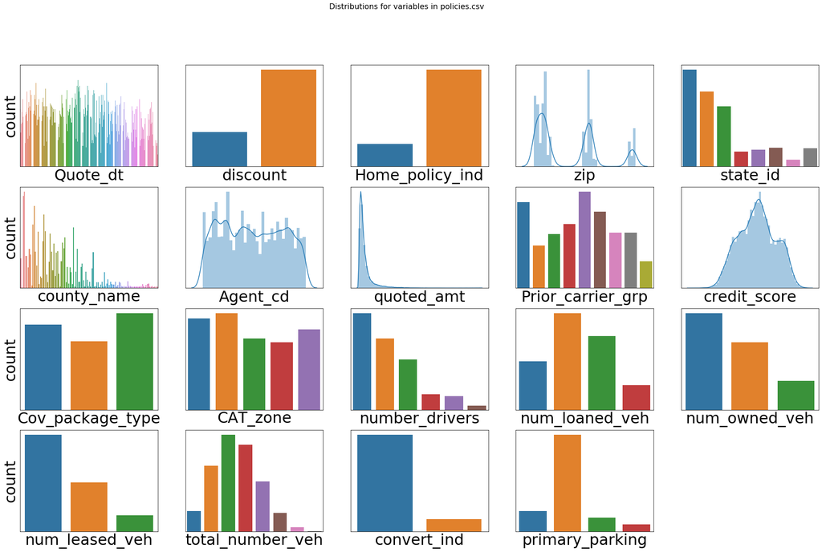

```python
plt_dist(df, row=4, col=5, title='Distributions for variables in policies.csv')
```

Comments:

- The distribution is very good. Quoted amount seems to be right skewed, however the relatively large sample proportion is small. Therefore we don't have to worry about that.

### Check correlation among features

#### Filling missing values in order to calculate correlation (for the first time)

We also need to encode all character to integer. Also, pure nominal features make no sense to calculate pearson correlation.

```python
corr_df = df[df['convert_ind'].notna()].copy()

corr_df['discount'] = df['discount'].apply(lambda x: 1 if x=='Yes' else 0)
corr_df['Home_policy_ind'] = df['Home_policy_ind'].apply(lambda x: 1 if x=='Y' else 0)
corr_df['convert_ind'] = corr_df['convert_ind'].astype('int64')
corr_df['zip'] = corr_df['zip'].fillna(0).astype('int64')
corr_df['Agent_cd'] = corr_df['Agent_cd'].fillna(0).astype('int64')
corr_df['credit_score'] = corr_df['credit_score'].fillna(round(corr_df['credit_score'].mean()))
corr_df['quoted_amt'] = corr_df['quoted_amt'].fillna(round(corr_df['quoted_amt'].mean()))
corr_df['CAT_zone'] = corr_df['CAT_zone'].fillna(0).astype('int64')
corr_df['Cov_package_type'] = corr_df['Cov_package_type'].fillna('Medium')
corr_df['Cov_package_type'].replace({'High':2, 'Medium':1, 'Low':0})

col = ['discount', 'Home_policy_ind', 'quoted_amt',
       'credit_score', 'CAT_zone', 'Cov_package_type',
       'number_drivers', 'num_loaned_veh', 'num_owned_veh', 'num_leased_veh',
       'total_number_veh', 'convert_ind']

dic = {'High':2, 'Medium':1, 'Low':0}
corr_df['Cov_package_type'] = corr_df['Cov_package_type'].map(dic)

corr_df = corr_df[col].astype('float64')
```

Heatmap

```python
corr_df[col].corr()
```

|  | discount | Home_policy_ind | quoted_amt | credit_score | CAT_zone | Cov_package_type | number_drivers | num_loaned_veh | num_owned_veh | num_leased_veh | total_number_veh | convert_ind |
| --- | --- | --- | --- | --- | --- | --- | --- | --- | --- | --- | --- | --- |
| discount | 1.000000 | 0.804770 | -0.010834 | 0.037587 | -0.014459 | -0.021369 | 0.004254 | -0.004960 | 0.007212 | -0.000851 | 0.000144 | 0.042854 |
| Home_policy_ind | 0.804770 | 1.000000 | -0.006224 | 0.027363 | -0.014246 | -0.015339 | 0.001080 | -0.006174 | 0.000861 | 0.002683 | -0.002357 | 0.034199 |
| quoted_amt | -0.010834 | -0.006224 | 1.000000 | -0.549015 | 0.196427 | 0.355831 | -0.012791 | -0.000792 | 0.004573 | 0.004863 | 0.004388 | -0.076101 |
| credit_score | 0.037587 | 0.027363 | -0.549015 | 1.000000 | -0.242839 | -0.453809 | 0.010257 | 0.010006 | -0.002512 | 0.000168 | 0.005475 | 0.072107 |
| CAT_zone | -0.014459 | -0.014246 | 0.196427 | -0.242839 | 1.000000 | 0.524650 | -0.009647 | -0.001344 | 0.011236 | 0.000072 | 0.005235 | -0.075797 |
| Cov_package_type | -0.021369 | -0.015339 | 0.355831 | -0.453809 | 0.524650 | 1.000000 | -0.009741 | 0.000613 | 0.005706 | -0.005548 | 0.000735 | -0.080492 |
| number_drivers | 0.004254 | 0.001080 | -0.012791 | 0.010257 | -0.009647 | -0.009741 | 1.000000 | 0.005592 | 0.004022 | -0.002336 | 0.004791 | -0.063590 |
| num_loaned_veh | -0.004960 | -0.006174 | -0.000792 | 0.010006 | -0.001344 | 0.000613 | 0.005592 | 1.000000 | 0.002791 | -0.002006 | 0.675755 | 0.003471 |
| num_owned_veh | 0.007212 | 0.000861 | 0.004573 | -0.002512 | 0.011236 | 0.005706 | 0.004022 | 0.002791 | 1.000000 | -0.005786 | 0.542523 | 0.003428 |
| num_leased_veh | -0.000851 | 0.002683 | 0.004863 | 0.000168 | 0.000072 | -0.005548 | -0.002336 | -0.002006 | -0.005786 | 1.000000 | 0.496573 | -0.000971 |
| total_number_veh | 0.000144 | -0.002357 | 0.004388 | 0.005475 | 0.005235 | 0.000735 | 0.004791 | 0.675755 | 0.542523 | 0.496573 | 1.000000 | 0.003720 |
| convert_ind | 0.042854 | 0.034199 | -0.076101 | 0.072107 | -0.075797 | -0.080492 | -0.063590 | 0.003471 | 0.003428 | -0.000971 | 0.003720 | 1.000000 |

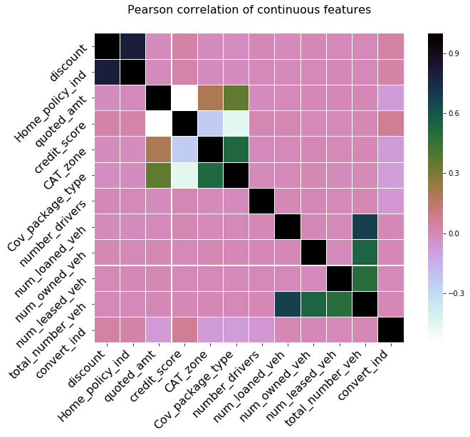

```python
heat_map(corr_df, col, title='Pearson correlation of continuous features')
```

```python
## TODO: Implement those two measures and plot the heatmap.
```

**Remark**:

- After finishing the feature engineering we should repeat all those preceudres again to ensure we have correct final results.
- We can apply the same procedure to other two files, but we're not going to show it here.

## Feature engineering

Generally speaking, we can create/aggregate/delete a feature. This part is more related with specific problem, and might depending on the field knowledge.

### Merge from other files

Useful aggregation function:

- pd.groupby()
- pd.pivot_table()

```python
driver_df = pd.read_csv('data/drivers.csv', index_col=0)
```

Filling missing values

```python
driver_df.loc[driver_df['living_status'].isna(), 'living_status'] = 'own'
driver_df.loc[driver_df['safty_rating'].isna(), 'safty_rating'] = driver_df['safty_rating'].mean()
driver_df['high_education_ind'] = driver_df['high_education_ind'].fillna(0)
```

Create the number of living dependent &gender (Which are showed that not important)

```python
sm = driver_df.groupby(['policy_id','living_status']).size().unstack('living_status', fill_value=0)
policy_df = pd.merge(policy_df, sm, on='policy_id')
```

```python
se = driver_df.groupby(['policy_id','gender']).size().unstack('gender', fill_value=0)
policy_df = pd.merge(policy_df, se, on='policy_id')
```

Create the number of high_education_ind for each policy

```python
sd = driver_df.groupby(['policy_id','high_education_ind']).size().unstack('high_education_ind', fill_value=0)
sd
```

| high_education_ind policy_id | 0.0 | 1.0 |
| --- | --- | --- |
| policy_100 | 1 | 1 |
| policy_1000 | 0 | 1 |
| policy_10001 | 2 | 1 |
| policy_10002 | 4 | 1 |
| policy_10004 | 4 | 1 |
| ... | ... | ... |
| policy_99994 | 3 | 0 |
| policy_99996 | 1 | 0 |
| policy_99997 | 0 | 2 |
| policy_99998 | 1 | 0 |
| policy_99999 | 1 | 1 |

49162 rows × 2 columns

```python
sd['high_education_ind'] = sd.loc[:,1]/(sd.loc[:,0]+sd.loc[:,1])
```

```python
policy_df = pd.merge(policy_df, sd['high_education_ind'], on='policy_id')
```

```python
# Discard
# tp = driver_df.pivot_table(index='policy_id', columns='living_status', values='high_education_ind', aggfunc=len, fill_value=0)
# sum(tp.sum(axis=1) == 0)  # No missing values
```

Aggregate min/max age and min/max safty rating

```python
ad = driver_df.groupby(['policy_id']).agg(maxage=('age','max'), mixage=('age','min'),
                                          maxrate=('safty_rating','max'), minrate=('safty_rating','min'), )
policy_df = pd.merge(policy_df, ad, on='policy_id')
```

Add mean age and rating

```python
te = driver_df.groupby(['policy_id']).agg({'age': 'mean', 'safty_rating': 'mean'})
policy_df = pd.merge(policy_df, te, on='policy_id')
```

From vehicles

```python
veh_df = pd.read_csv('data/vehicles.csv', index_col=0)
```

```python
veh_df['age'] = veh_df['age'].fillna(veh_df['age'].mean())
```

```python
model = veh_df['make_model'].values
set(map(lambda s: s[:s.index(':')-1], model))
veh_df['make_model'] = list(map(lambda s: s[:s.index(':')-1], model))
tm = veh_df.groupby(['policy_id', 'make_model']).size().unstack('make_model', fill_value=0)
policy_df = pd.merge(policy_df, tm[['BMW', 'MERCEDES-BENZ']], on='policy_id')
```

```python
policy_df = pd.merge(policy_df, veh_df.groupby(['policy_id']).agg({'age': 'mean'}), on='policy_id')
```

```python
policy_df = policy_df.rename(columns={"age_x": "age", "age_y": "ave_age"})
```

```python
policy_df = policy_df.drop(['num_loaned_veh', 'num_owned_veh',
       'num_leased_veh', 'total_number_veh'], axis=1)
tn = pd.crosstab(veh_df['policy_id'], veh_df['ownership_type'])
tn['total_number_veh'] = tn.sum(axis=1)
policy_df = pd.merge(policy_df, tn, on='policy_id')
```

### Create

Split quote_dt to year and month

```python
policy_df['year'] = policy_df['Quote_dt'].apply(lambda s: s[:4])
policy_df['month'] = policy_df['Quote_dt'].apply(lambda s: s[5:7])
policy_df['year_month'] = policy_df['year'].apply(str)+policy_df['month'].apply(str)
```

Calculate the difference between each data and earliest data

```python
from datetime import datetime

def days_between(d1, d2):
    d1 = datetime.strptime(d1, "%Y-%m-%d")
    d2 = datetime.strptime(d2, "%Y-%m-%d")
    return abs((d2 - d1).days)
```

```python
early = min(policy_df['Quote_dt'])
policy_df['Date'] = policy_df['Quote_dt'].apply(lambda s: days_between(s, early))
```

Merge state and county name

```python
policy_df['state_county'] = policy_df['state_id']+policy_df['county_name']
```

### Aggregate

Center the credit score

```python
policy_df['credit_score'] = policy_df['credit_score']-policy_df['credit_score'].min()
```

### Delete

```python
lst = ['Quote_dt', 'state_id', 'county_name', 'Home_policy_ind', 'leased', 'owned', 'year', 'month', 'primary_parking']
policy_df = policy_df.drop(lst, axis=1)
```

```python
policy_df.to_csv('data/policies_n.csv')
```

## Model

Thoughts: Linear model will never be good in those kind of tasks. We aim on boosting model in this notebook, especially Lightgbm for its super performance and several advantanges like automatically dealing with categorical data. However, I believe NN model could achieve best performance.

### Packages & prepration

```python
import lightgbm as lgb
import time

from sklearn.metrics import roc_auc_score
from sklearn.model_selection import train_test_split, KFold
from sklearn.model_selection import GridSearchCV
from sklearn.preprocessing import LabelEncoder
```

```python
policy_df = pd.read_csv('data/policies_n.csv', index_col=0)
```

```python
policy_df = policy_df.sample(frac=1).reset_index(drop=True)  # shuffle
```

```python
policy_df.columns.values, len(policy_df.columns.values)
```

[output not shown]

Split data

```python
policy_df = pd.read_csv('data/policies_n.csv', index_col=0)
cat = ['discount', 'Prior_carrier_grp', 'Cov_package_type', 'year_month',
       'zip', 'Agent_cd', 'CAT_zone', 'state_county']

policy_df[policy_df['split'] == 'Train']['convert_ind'] = policy_df[policy_df['split'] == 'Train']['convert_ind'].astype('int64')
lst = ['Home_policy_ind', 'leased', 'owned', 'year', 'month', 'primary_parking']
policy_df = policy_df.drop(lst, axis=1)


# fillna with 0 or mean first
policy_df['zip'] = policy_df['zip'].fillna(0).astype('int64')
policy_df['Agent_cd'] = policy_df['Agent_cd'].fillna(0).astype('int64')
policy_df['CAT_zone'] = policy_df['CAT_zone'].fillna(0)
policy_df['Cov_package_type'] = policy_df['Cov_package_type'].fillna('Medium')

fill = ['credit_score', 'quoted_amt']
policy_df[fill] = policy_df[fill].fillna(policy_df[fill].mean())

# Categorical data to int
for col in cat:
    le = LabelEncoder()
    policy_df[col] = le.fit_transform(list(policy_df[col].astype(str).values))
```

### Lgbm

#### Parameter tuning

```python
def test_score(test, model):
    dtest_predprob = model.predict_proba(test[predictors])[:,1]
    print("AUC Score (Test): %f" % roc_auc_score(test[target], dtest_predprob))
```

```python
ptrain = policy_df[policy_df['split'] == 'Train'].drop('split', axis=1)
msk = np.random.rand(len(ptrain)) < 0.75
df = ptrain.drop(['policy_id'], axis=1)
X_train, X_test, y_train, y_test = train_test_split(df.drop(['convert_ind'], axis=1), df['convert_ind'], test_size=0.25)
train, test = df[msk], df[~msk]

predictors = X_test.columns.values
target = 'convert_ind'
```

```python
params = {
    'objective': 'binary',
    'boost': 'gbdt',  # alternative: rf, dart,
    'tree_learner': 'serial',
    'metric':'auc',
    'num_threads': -1,
    'is_provide_training_metric': True,

    'learning_rate': 0.01,

    'num_leaves': 40,
    'max_depth': -1,
    'min_data_in_leaf': 50,  # large for control over-fitting
    'min_sum_hessian_in_leaf': 10.0,    # large for control over-fitting

    'bagging_freq': 3,
    'bagging_fraction': 0.7,
    'boost_from_average':'false',
    'feature_fraction': 0.8,

    'reg_alpha': 1,
    'reg_lambda': 3,

    'verbosity': 1
}
```

**Automatically tuning by sequencial grid search**

```python
# Fit a lgbm by random initial parameters first to choose best current number of iterations.
lgb1 = lgb.LGBMClassifier(**params)
modelfit(lgb1, train, predictors)
# test_score(test, lgb1)  ## To look at the performance on test dataset
params['n_estimators'] = lgb1.get_params()['n_estimators']
```

```python
%%time
# Choose number of leavers and min data in single leaf to control overfitting.
param_test = {
 'num_leaves':range(20,100,20),
 'min_data_in_leaf':range(20,100,20)
}
res = grid_searchCV(estimator = lgb1, param_grid = param_test, scoring='roc_auc', iid=False, cv=5)
```

```
AUC Score (Test): 0.671794
{'min_data_in_leaf': 80, 'num_leaves': 40} 0.6713236761472384
CPU times: user 2min 4s, sys: 4.9 s, total: 2min 9s
Wall time: 17.6 s
```

```python
# finer grid for those two parameters
res = grid_searchCV(estimator = lgb1, param_grid = clip(param_test), scoring='roc_auc', iid=False, cv=5)
```

```python
# For overfitting as well.
param_test = {
 'min_sum_hessian_in_leaf':[i for i in range(11,20,2)]
}
res = grid_searchCV(estimator = lgb.LGBMClassifier(**params),
                    param_grid = param_test, scoring='roc_auc',
                    iid=False, cv=5)
```

```python
# Turn to other features, refit the model and find new number of iterations.
params.update({'n_estimators':2000})
lgb2 = lgb.LGBMClassifier(**params)
modelfit(lgb2, train, predictors)
test_score(test, lgb2)
```

```python
# Tuning fraction of obs and features to avoid overfitting.
params = lgb2.get_params()
param_test = {
 'bagging_fraction':[i/10.0 for i in range(7,10)],
 'feature_fraction':[i/10.0 for i in range(7,10)]
}
res = grid_searchCV(estimator = lgb2, param_grid = param_test, scoring='roc_auc', iid=False, cv=5)
```

```python
# Finer grid
param_test = clip(res,size=4,scale=100)
res = grid_searchCV(estimator = lgb.LGBMClassifier(**params), param_grid = param_test, scoring='roc_auc', iid=False, cv=5)
```

```python
# Tuning penalty parameters.
param_test = {
 'reg_alpha':[1e-2, 0.1, 1, 10, 100],
#  'reg_lambda':[1e-2, 0.1, 1, 10, 100]
}
res = grid_searchCV(estimator = lgb.LGBMClassifier(**params), param_grid = param_test, scoring='roc_auc', iid=False, cv=5)
```

```python
params.update({'n_estimators':5000, 'learning_rate':0.01})
lgb3 = lgb.LGBMClassifier(**params)
modelfit(lgb3, train, predictors)
test_score(test, lgb3)
```

AUC curve

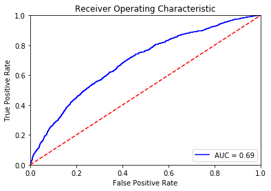

```python
from sklearn.metrics import roc_curve, auc
# calculate the fpr and tpr for all thresholds of the classification
preds = lgb3.predict_proba(test[predictors])[:,1]
fpr, tpr, threshold = roc_curve(test[target], preds)
roc_auc = auc(fpr, tpr)


plt.title('Receiver Operating Characteristic')
plt.plot(fpr, tpr, 'b', label = 'AUC = %0.2f' % roc_auc)
plt.legend(loc = 'lower right')
plt.plot([0, 1], [0, 1],'r--')
plt.xlim([0, 1])
plt.ylim([0, 1])
plt.ylabel('True Positive Rate')
plt.xlabel('False Positive Rate')
```

#### Cross Validation for final model

```python
policy_train_df = policy_df[policy_df['split'] == 'Train'].drop('split', axis=1)
policy_test_df = policy_df[policy_df['split'] == 'Test'].drop('split', axis=1)
ptrain, ptest = policy_train_df.copy(), policy_test_df.copy()
X, y = ptrain.drop(['convert_ind', 'policy_id'], axis=1), ptrain['convert_ind']
X_test = ptest.drop(['policy_id'], axis=1)
X.columns, len(X.columns)
```

```
(Index(['discount', 'zip', 'Agent_cd', 'quoted_amt', 'Prior_carrier_grp',
        'credit_score', 'Cov_package_type', 'CAT_zone', 'number_drivers',
        'year_month', 'Date', 'state_county', 'high_education_ind', 'maxage',
        'mixage', 'maxrate', 'minrate', 'age', 'safty_rating', 'BMW',
        'MERCEDES-BENZ', 'ave_age', 'loaned', 'total_number_veh'],
       dtype='object'), 24)
```

```
Fold 1 started at Sat Dec 21 00:19:54 2019
Training until validation scores don't improve for 200 rounds
Early stopping, best iteration is:
[474]	training's auc: 0.788924	valid_1's auc: 0.706789
Fold 2 started at Sat Dec 21 00:19:57 2019
Training until validation scores don't improve for 200 rounds
[1000]	training's auc: 0.862934	valid_1's auc: 0.705096
Early stopping, best iteration is:
[800]	training's auc: 0.837883	valid_1's auc: 0.707279
Fold 3 started at Sat Dec 21 00:20:01 2019
Training until validation scores don't improve for 200 rounds
[1000]	training's auc: 0.864071	valid_1's auc: 0.703218
Early stopping, best iteration is:
[1439]	training's auc: 0.905288	valid_1's auc: 0.704687
Fold 4 started at Sat Dec 21 00:20:09 2019
Training until validation scores don't improve for 200 rounds
Early stopping, best iteration is:
[745]	training's auc: 0.830724	valid_1's auc: 0.702735
Fold 5 started at Sat Dec 21 00:20:12 2019
Training until validation scores don't improve for 200 rounds
Early stopping, best iteration is:
[538]	training's auc: 0.799923	valid_1's auc: 0.691767
Fold 6 started at Sat Dec 21 00:20:16 2019
Training until validation scores don't improve for 200 rounds
Early stopping, best iteration is:
[532]	training's auc: 0.798846	valid_1's auc: 0.701425
Fold 7 started at Sat Dec 21 00:20:19 2019
Training until validation scores don't improve for 200 rounds
[1000]	training's auc: 0.86245	valid_1's auc: 0.686718
Early stopping, best iteration is:
[1025]	training's auc: 0.865189	valid_1's auc: 0.687111
Fold 8 started at Sat Dec 21 00:20:24 2019
Training until validation scores don't improve for 200 rounds
Early stopping, best iteration is:
[748]	training's auc: 0.830831	valid_1's auc: 0.706351
Fold 9 started at Sat Dec 21 00:20:28 2019
Training until validation scores don't improve for 200 rounds
Early stopping, best iteration is:
[641]	training's auc: 0.815125	valid_1's auc: 0.703492
Fold 10 started at Sat Dec 21 00:20:33 2019
Training until validation scores don't improve for 200 rounds
Early stopping, best iteration is:
[774]	training's auc: 0.834638	valid_1's auc: 0.693067
CV mean score: 0.7005, std: 0.0068.
CPU times: user 5min 27s, sys: 3.38 s, total: 5min 30s
Wall time: 45 s
```

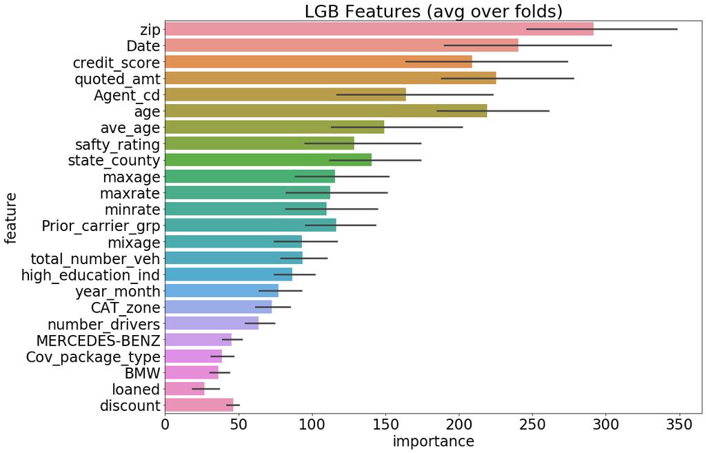

```python
%%time
np.random.seed(1024)
font = {'size'   : 24}

plt.rc('font', **font)

n_fold = 10
folds = KFold(n_splits=n_fold)
result_dict_lgb = train_model_classification(X=X,
                                             X_test=X_test,
                                             y=y,
                                             params=params, folds=folds, model_type='lgb', eval_metric='auc',
                                             plot_feature_importance=True,
                                                      verbose=1000, early_stopping_rounds=200,
                                             n_estimators=5000, averaging='usual', n_jobs=-1)
```

### Predict & save results

```python
y_pred = result_dict_lgb['prediction'].reshape(-1)

submission = pd.DataFrame({
    "policy_id": policy_test_df["policy_id"],
    "conv_prob": y_pred
})
# submission.to_csv('output/submission.csv', index=False, mode='w')
```